# Lab 02 - Global plastic waste

# Academic integrity and honor code

This lab is designed to help you build your own fluency with R, RStudio, Git, and GitHub. **Generative AI tools are not permitted for this assignment.** This includes ChatGPT, Claude, Gemini, Copilot, Grok, and similar tools that can generate or revise code, written answers, interpretations, or assignment content.

By completing and submitting this lab, I certify that:

- I completed the submitted work myself.
- I did not use generative AI to generate, debug, revise, or interpret code or written answers for this assignment.
- I may use course materials, lecture notes, R documentation/help files, and other resources explicitly approved by the instructors.
- I understand that I am responsible for being able to explain all code and written work that I submit.

**Name:** ______________________________  
**Signature:** ___________________________  
**Date:** _______________________________

> **Important:** Signing this statement is part of the assignment. The same statement appears in your starter file; complete it there as well.

# Lab overview

Plastic pollution is a major and growing problem, negatively affecting oceans and wildlife health. [Our World in Data](https://ourworldindata.org/plastic-pollution) publishes plastic-waste data globally, by country, and over time. This lab focuses on country-level data from **2010**.

National Geographic also ran a data-visualization communication contest on plastic waste, which you can browse [here](https://www.nationalgeographic.org/funding-opportunities/innovation-challenges/plastic/dataviz/).

You already practiced the GitHub + RStudio Cloud workflow in Lab 01. The steps below are a short review.

## Learning goals

By the end of this lab, you should be able to:

A. Visualize numerical and categorical data with histograms, density plots, box plots, violin plots, and scatterplots. B. Choose plot types and `ggplot2` settings (faceting, transparency, color) that make comparisons readable. C. Interpret the shape, center, spread, outliers, and associations you see in a plot. D. Recreate a visualization from a description and a target figure. E. Keep building fluency with R, RStudio, Git, and GitHub.

## Deliverable

Complete **`lab-02-starter.Rmd`**. Your finished starter file should contain your code, plots, and written responses and should Knit successfully from top to bottom.

**The instructions file tells you what to do; the starter file is where your assignment work belongs, except for completing the honor-code signature above.**

## Reproducibility rule

Throughout EAES 380, your analysis should work **from top to bottom**. Code that works only because you previously ran something in the Console is not reproducible.

**Knit frequently.** Knitting is one of the best ways to discover whether your document actually contains everything needed to reproduce your work.

## Before asking for help

First check:

- Did you run the relevant chunks from top to bottom?
- Did you spell every object and variable name exactly as shown? R is case-sensitive.
- Are all parentheses, quotation marks, and backticks closed?
- Did you load the packages needed by your code?
- Does the error message point to a particular chunk or line?
- Have you tried Knitting the document to identify where the problem first occurs?

If you still cannot resolve the problem, ask your instructor or TA and show them the code and error message.

# Getting started

Each assignment begins with a similar workflow.

**If you are reading a Knitted version of these instructions, you may already have completed these steps. Treat them as review.**

## Create your copy of the course repository

- Open the GitHub repository you want to copy (for example, `unit-1`).
- Add `/generate` to the end of the repository URL and press Return/Enter.
- Under **Owner**, choose `EAES-380`. **Do not choose your personal account.**
- Under **Repository name**, enter `unit-X-yourlastname`.
  - For example: `unit-1-mcnicol`.
- You can leave **Description** blank.
- Confirm that the repository is **Private**.
- Click **Create repository**.

## Create your RStudio Cloud project

- Copy the URL of your generated repository using the green **Code** button on GitHub.
- Clone it into a **New Project from a GitHub Repo** in [RStudio Cloud](https://rstudio.cloud).
- Use the **Files** pane to navigate to the appropriate exercise, lab, or homework folder.
- Open `lab-02-instructions.Rmd` and Knit it.
- Open `lab-02-starter.Rmd`. **This is the file you will complete.**

# Warm-up: R Markdown + Git

The section at the top of an R Markdown file between the two sets of three dashes is called YAML. It contains metadata and output settings for the document.

Open `lab-02-starter.Rmd`.

A. Replace `Insert your name here` with your name. B. Replace `Insert date here` with today’s date. C. Complete and sign the honor-code statement. D. Knit the document.

Then, in the **Git** pane:

- Commit with a message such as `Update author and honor code`.
- Push your changes to GitHub.
- Open the repository on GitHub and confirm that the updated `.Rmd` file is visible. If anything is missing, commit and push again.

# Packages and data

## Load packages

We will use the **tidyverse** package for this analysis. The package is already **installed**, but you must still **load** it into each new R session.

Navigate to `lab-02-starter.Rmd` and run the `load-packages` chunk.

```r
library(tidyverse)
```

## Load the data

The dataset lives in the `data` folder of your repository. Read it in with the `load-data` chunk in your starter file (or run the code below in the Console while you explore).

```r
plastic_waste <- read_csv("data/plastic-waste.csv")
```

**Hint:** “Per capita” means “per person.”

Variable descriptions:

- `code`: 3-letter country code
- `entity`: Country name
- `continent`: Continent name
- `year`: Year
- `gdp_per_cap`: GDP per capita, constant 2011 international dollars
- `plastic_waste_per_cap`: Plastic waste per capita in kg/day
- `mismanaged_plastic_waste_per_cap`: Mismanaged plastic waste per capita in kg/day
- `mismanaged_plastic_waste`: Tonnes of mismanaged plastic waste
- `coastal_pop`: Number of people living on or near the coast
- `total_pop`: Total population according to Gapminder

A few countries that span Europe and Asia appear twice in the table, once under each continent. That is a feature of how this file was compiled, not an error in your code.

# Navigating RStudio Cloud

Answer the warm-up questions in your starter file.

- Recall that RStudio is divided into four panes. Without looking, can you name them all and briefly describe their purpose?
- Verify that the dataset has loaded into the Environment. How many observations (rows) are in the dataset? Click the data frame in the Environment to inspect it, or type `View(plastic_waste)` in the Console.
- Have a quick look at the data and notice that some cells take the value `NA`. What does `NA` mean?

**Hint:** If you are not sure what `NA` means, run `?NA` in the Console to open the documentation.

# Exercises

For each exercise:

A. Read the prompt here. B. Complete the corresponding section in `lab-02-starter.Rmd`. C. Run your code and inspect the output. D. Write any requested interpretation in complete sentences. E. Knit before moving on when a checkpoint is indicated.

**Note:** Code chunk labels are already provided for all eight exercises (for example, `{r plastic-waste-continent}`). If you add any new chunks of your own, give them a label too.

Let’s start by looking at the distribution of plastic waste per capita in 2010 using `geom_histogram()`.

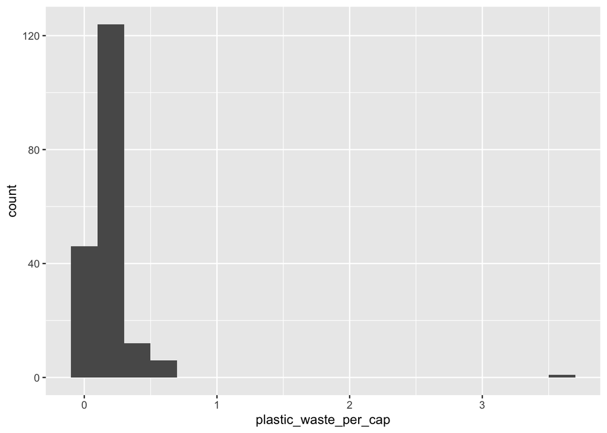

```r
ggplot(data = plastic_waste, aes(x = plastic_waste_per_cap)) +
  geom_histogram(binwidth = 0.2)
```

`ggplot2` drops missing values from the plotted variable and may print a warning. That is expected here: many countries do not have a recorded plastic-waste value.

One country stands out as an unusual observation at the high end of the distribution.

One way to identify that country is to filter the data for countries where plastic waste per capita is **greater than 3.5 kg/day**.

```r
plastic_waste %>%
  filter(plastic_waste_per_cap > 3.5)
```

```
## # A tibble: 1 × 10
##   code  entity              continent     year gdp_per_cap plastic_waste_per_cap
##   <chr> <chr>               <chr>        <dbl>       <dbl>                 <dbl>
## 1 TTO   Trinidad and Tobago North Ameri…  2010      31261.                   3.6
## # ℹ 4 more variables: mismanaged_plastic_waste_per_cap <dbl>,
## #   mismanaged_plastic_waste <dbl>, coastal_pop <dbl>, total_pop <dbl>
```

Did you expect this result?

You might look up Trinidad and Tobago to see why plastic waste per capita is so high there, or whether this value is a data error. Either way, keep this country in mind: it will pull the scale of several later plots.

## Exercise 1 — Faceted histograms by continent

**Goal:** Compare the distribution of a numerical variable across levels of a categorical variable.

Plot, using **histograms**, the distribution of plastic waste per capita **faceted by continent**.

- What can you say about how the continents compare to each other in terms of plastic waste per capita?

A useful starting point is the histogram above plus `facet_wrap(~ continent)`. You may reuse `binwidth = 0.2` or choose a bin width that makes the comparison readable.

### Exercise 1 checkpoint

🧶 ✅ ⬆️ **Knit, commit, and push.** Suggested commit message: `Complete Exercise 1`.

–

**NOTE:** From this point onward, the plots and printed output are not displayed in these instructions. Run the demonstration chunks in this file or type them into your starter file so that you can see the output yourself.

Then, for each exercise, write the required code in `lab-02-starter.Rmd` and interpret what you see.

Another way of visualizing numerical data is a **density plot**.

```r
ggplot(data = plastic_waste, aes(x = plastic_waste_per_cap)) +
  geom_density()
```

We can also compare density distributions across continents by mapping continent to the color of the curves.

```r
ggplot(data = plastic_waste,
       mapping = aes(x = plastic_waste_per_cap,
                     color = continent)) +
  geom_density()
```

The resulting plot may be a little difficult to read, so let’s also fill the curves.

```r
ggplot(data = plastic_waste,
       mapping = aes(x = plastic_waste_per_cap,
                     color = continent,
                     fill = continent)) +
  geom_density()
```

Hmm, still not ideal.

Overlapping fills make it difficult to see the continents that were plotted first, because later layers sit on top of them.

We can change the transparency of the fill with the `alpha` argument. `alpha` takes values between 0 and 1: 0 is completely transparent and 1 is completely opaque.

There is no single “correct” value. Try a few.

```r
ggplot(data = plastic_waste,
       mapping = aes(x = plastic_waste_per_cap,
                     color = continent,
                     fill = continent)) +
  geom_density(alpha = 0.7)
```

This still does not look great…

## Exercise 2 — Density plots with a better alpha

**Goal:** Use transparency so that overlapping distributions remain visible.

Recreate the filled density plots above using a **lower** alpha level that works better for displaying the density curves for all continents.

## Exercise 3 — Mapped aesthetics vs. geom arguments

**Goal:** Distinguish variables that are mapped from data and settings that are fixed by you.

In 1–2 complete sentences, explain why we defined the `color` and `fill` of the curves by **mapping aesthetics** of the plot, but we defined the `alpha` level as an argument of the plotting geom.

### Exercise 3 checkpoint

🧶 ✅ ⬆️ **Knit, commit, and push.** Suggested commit message: `Complete Exercises 2 and 3`.

–

Another way to compare a numerical variable across groups is with side-by-side **box plots**.

```r
ggplot(data = plastic_waste,
       mapping = aes(x = continent,
                     y = plastic_waste_per_cap)) +
  geom_boxplot()
```

## Exercise 4 — Violin plots

**Goal:** Compare what box plots and violin plots each make visible.

Convert the side-by-side box plots from the previous chunk to [violin plots](https://ggplot2.tidyverse.org/reference/geom_violin.html).

Then answer both questions in complete sentences:

- What do the violin plots reveal that the box plots do not?
- What features are apparent in the box plots but not in the violin plots?

### Exercise 4 checkpoint

🧶 ✅ ⬆️ **Knit, commit, and push.** Suggested commit message: `Complete Exercise 4`.

–

**Remember:** We use `geom_point()` to make scatterplots.

## Exercise 5 — Plastic waste vs. mismanaged waste

**Goal:** Describe the association between two numerical variables.

Visualize the relationship between plastic waste per capita and mismanaged plastic waste per capita using a scatterplot.

- Describe the relationship in 2–3 complete sentences.

## Exercise 6 — Color points by continent

**Goal:** Use color to check whether an overall pattern is the same in every group.

Color the points in the scatterplot by continent.

- Does there seem to be any clear distinction among continents in how plastic waste per capita and mismanaged plastic waste per capita are associated?

## Exercise 7 — Waste vs. population size

**Goal:** Compare the strength of two associations using separate scatterplots.

Visualize the relationship between plastic waste per capita and total population, and the relationship between plastic waste per capita and coastal population.

- You will need to make two separate plots.
- Do either of these pairs of variables appear to be more strongly linearly associated?

### Exercise 7 checkpoint

🧶 ✅ ⬆️ **Knit, commit, and push.** Suggested commit message: `Complete Exercises 5–7`.

# Wrapping up

If you still have time in class, move on to Exercise 8. If not, finish it after class.

If you have not finished the earlier exercises by the end of class, ask your instructor or TA for help rather than leaving plots or interpretations blank.

**Hint:** The x-axis is a calculated variable. One country with plastic waste per capita over 3 kg/day has been filtered out. The data are shown with points and with a smooth curve. The word “smooth” should help you [pick which geom to use](https://ggplot2.tidyverse.org/reference/index.html#section-geoms).

## Exercise 8 — Recreate and interpret a plot

**Goal:** Rebuild a complete `ggplot2` figure from a target plot and interpret it in context.

Recreate the following plot in your starter file (copying and pasting the code is fine) and interpret what you see in the context of the data.

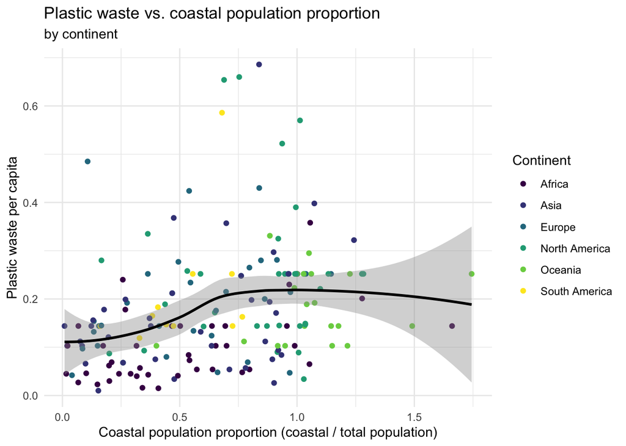

Your written interpretation should address the overall pattern, what the smooth curve is doing, and what the plot suggests about countries with a large share of people living on the coast. Two to four complete sentences is enough.

### Exercise 8 checkpoint

🧶 ✅ ⬆️ Knit, commit, and push your changes to GitHub with an appropriate commit message (for example, `Complete Lab 2`). Make sure you commit and push **all** changed files so that the Git pane is clear, then review the `.Rmd` file on GitHub to confirm you are happy with the final state of your work.

Once you are done, open the GitHub folder that contains this lab and confirm that your latest commit is there.

[figure not shown]

# Submission checklist

Before you finish, confirm that:

- I signed the academic-integrity statement in both the instructions and starter files.
- My name and date are correct in the starter-file YAML.
- I answered every requested question in complete sentences.
- All required code is contained in the starter `.Rmd` file, not only in the Console.
- My plots and numerical outputs appear as expected.
- I ran the analysis from top to bottom.
- `lab-02-starter.Rmd` Knits without errors.
- I committed and pushed all final changes to GitHub.
- My Git pane is clear and the latest files are visible in my GitHub repository.

🧶 ✅ ⬆️ **Final step:** Knit, commit all remaining changes with a message such as `Complete Lab 2`, and push them to GitHub.